[figure not shown]

МИНОБРНАУКИ РОССИИ  
Федеральное государственное бюджетное образовательное учреждение высшего образования  
**«МИРЭА – РОССИЙСКИЙ ТЕХНОЛОГИЧЕСКИЙ УНИВЕРСИТЕТ»**  
Лабораторная работа по дисциплине:  
«Программные средства оперативно-аналитического поиска»  
Тема: Сбор информации о компаниях

*Выполнил:* студент 4 курса,  
специальности 10.05.05,  
группы ББСО-02-16,  
Прибылов И.А.  
*Проверил:* Захарчук И.И.

Москва, 2020

**Цель работы:**

| **Собрать информацию о компаниях из списка S&P 500** |
| --- |

**Исходные данные:**

**1) OS Kali Linux**

[figure not shown]

[[kali-linux-2020]](https://www.kali.org/downloads/)

**2) Цели:**

- [*Progressive Corporation*](https://www.progressive.com/) - американская страховая компания;
- [*Analog Devices Inc.*](https://www.analog.com/en/index.html) - крупная американская компания, производитель интегральных микросхем для решения задач преобразования сигналов;
- [*Allstate Corporation*](https://www.allstate.com/) - американская страховая компания;
- [*SunTrust Banks Inc.*](https://suntrustng.com/) - американская банковская холдинговая компания;
- [*Sherwin-Willams Company*](https://www.sherwin-williams.com/) - крупнейший в мире производитель лакокрасочных материалов.

**Инструменты:**

**В ходе поиска информации мы будем использовать следующий инструментарий:**

- *2ip.ru* - портал сетевых сервисов;
- [*reg.ru*](https://www.reg.ru) - регистратор доменных имён;
- [Linkonavt.ru](https://linkonavt.ru/services/sitetechnologies) - определение используемых web-приложений;
- [*Nmap*](https://nmap.org/) - свободная утилита, предназначенная для разнообразного настраиваемого сканирования IP-сетей с любым количеством объектов, определения состояния объектов сканируемой сети (портов и соответствующих им служб).

**План выполнения работы:**

**1) С помощью сервиса 2ip.ru определим следующие признаки:**

- *IP-адрес;*
- *Местоположение;*
- *Телефонные номера;*
- *Электронные адреса e-mail.*

**2) Просканируем порты, используя операционную систему Linux, выполнив команду:**

```
nmap <домен_компании>/<ip_адрес> -p <номер_порта>
```

**3) При помощи сервиса REG.ru определим кто занимается хостингом данной компании;**

**4) Используем Linkonavt.ru, чтобы определить web-приложения по домену.**

**Progressive Corporation:**

**№**

**Признак**

**Значение**

**1**

Сайт

https://www.progressive.com/

**2**

IP-адрес

*170.218.212.32*  
**United States**

**3**

Местонахождение

**Address:** 300 NORTH COMMONS BLVD  
**City:** MAYFIELD VILLAGE  
**StateProv:** OH  
**PostalCode:** 44143  
**Country:** US

**4**

Телефон

Organisation: +1-877-669-6862 US  
Tech (Chumley, Scott): +1-440-603-3028 US  
Tech (Goodwin, James A.): +1-440-395-0088 US

**5**

E-mail

Organisation: ntoc@progressive.com  
Tech (Chumley, Scott): schumle1@progressive.com  
Tech (Goodwin, James A.): steven_iannetta@progressive.com  
Network Operations: arin_poc@progressive.com

**6**

Порты

All 1000 scanned ports on *170.218.212.32* are filtered

**7**

Хостинг

Name Server: ns1.progressive.com  
Name Server: ns7.progressive.com  
Name Server: ns5.progressive.com  
Name Server: ns3.progressive.com  
Регистратор: CSC CORPORATE DOMAINS, INC.

**8**

Web-технологии

[figure not shown]

**Analog Devices Inc.:**

**1**

Сайт

https://www.analog.com/

**2**

IP-адрес

*137.71.173.128*  
**United States**

**3**

Местонахождение

**Address:** Two Technology Way  
**City:** Norwood  
**StateProv:** MA  
**PostalCode:** 02062  
**Country:** US

**4**

Телефон

OrgTech (Analog DNS Administrator): +1-781-461-3040 US  
RTech (Analog Devices): +1-781-461-3719 US

**5**

E-mail

OrgTech: don.balunos@analog.com  
RTech: InternetServices@analog.com

**7**

Хостинг

Name Server: udns1.cscdns.net  
Name Server: udns2.cscdns.uk  
Регистратор: CSC CORPORATE DOMAINS, INC.

**8**

Web-технологии

[figure not shown]

**Allstate Corporation:**

| **1** | Сайт | https://www.allstate.com/ |
| --- | --- | --- |
| **2** | IP-адрес | *167.127.208.24* **United States** |
| **3** | Местонахождение | **Address:** 3075 Sanders Road **City:** Northbrook **StateProv:** IL **PostalCode:** 60062-7127 **Country:** US |
| **4** | Телефон | Domain Administrator: +1-847-402-5000 US |
| **5** | E-mail | Domain Administrator: dnsadmin@allstate.com |
| **6** | Порты |  |
| **7** | Хостинг | Name Server: ns1.allstate.com Name Server: ns1.allstate.com Регистратор: Brandsight, Inc. |
| **8** | Web-технологии | Нет данных |

**SunTrust Banks Inc.:**

**1**

Сайт

https://suntrustng.com/

**2**

IP-адрес

*107.180.25.42*  
**United States**

**3**

Местонахождение

**Address:** Suite 226  
**City:** Scottsdale  
**StateProv:** AZ  
**PostalCode:** 85260  
**Country:** US

**4**

Телефон

Network Operations Center: +1-480-505-8809 US  
Abuse Departament: +1-480-624-2505

**5**

E-mail

Network Operations Center: noc@godaddy.com  
Abuse Departament: abuse@godaddy.com

**6**

Порты

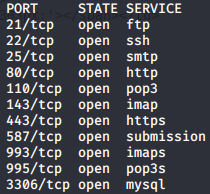

**7**

Хостинг

Name Server: ns49.domaincontrol.com  
Name Server: ns50.domaincontrol.com  
Регистратор: GoDaddy.com, LLC

**8**

Web-технологии

Web server: Apache  
Web framework: Bootstrap  
Database: MySQL  
Programming Language: PHP (v.7.2.26)

**Sherwin-Willams Company:**

**1**

Сайт

https://www.sherwin-williams.com/

**2**

IP-адрес

*169.44.56.48*  
**United States**

**3**

Местонахождение

**Address:** 101 W. Prospect Ave.  
**City:** Cleveland  
**StateProv:** OH  
**PostalCode:** 44115  
**Country:** US

**4**

Телефон

Jerry Kozik: +1-866-398-7638 US  
Admin phone (Michael Sura): +1-216-566-20-00  
Tech phone (John Jensen): +1-216-566-1783

**5**

E-mail

Admin email: hostmaster@sherwin.com  
Tech email: hostmaster@sherwin.com

**7**

Хостинг

Name Server: ns1.sherwin.com  
Name Server: ns2.sherwin.com  
Name Server: ns3.level3.net  
Name Server: ns4.level3.net  
Регистратор: CSC CORPORATE DOMAINS, INC.

**8**

Web-технологии

[figure not shown]

**Вывод:**

| **Мы произвели разведку целей, в дальнейшем найденную информацию можно будет использовать при выборе направления атаки на цель** |
| --- |